# Boqian_Mao_Biostat_620_Lab3

Author

Boqian Mao

## 1. Read in the data

```r
met <- read.csv("met_all.gz")
```

## 2. Check the dimensions, headers, footers

```r
dim(met)
```

```
[1] 2377343      30
```

2377343 rows and 30 columns

## 3. Take a look at all the variables (hint: use the str function).

```r
str(met)
```

```
'data.frame':   2377343 obs. of  30 variables:
 $ USAFID           : int  690150 690150 690150 690150 690150 690150 690150 690150 690150 690150 ...
 $ WBAN             : int  93121 93121 93121 93121 93121 93121 93121 93121 93121 93121 ...
 $ year             : int  2019 2019 2019 2019 2019 2019 2019 2019 2019 2019 ...
 $ month            : int  8 8 8 8 8 8 8 8 8 8 ...
 $ day              : int  1 1 1 1 1 1 1 1 1 1 ...
 $ hour             : int  0 1 2 3 4 5 6 7 8 9 ...
 $ min              : int  56 56 56 56 56 56 56 56 56 56 ...
 $ lat              : num  34.3 34.3 34.3 34.3 34.3 34.3 34.3 34.3 34.3 34.3 ...
 $ lon              : num  -116 -116 -116 -116 -116 ...
 $ elev             : int  696 696 696 696 696 696 696 696 696 696 ...
 $ wind.dir         : int  220 230 230 210 120 NA 320 10 320 350 ...
 $ wind.dir.qc      : chr  "5" "5" "5" "5" ...
 $ wind.type.code   : chr  "N" "N" "N" "N" ...
 $ wind.sp          : num  5.7 8.2 6.7 5.1 2.1 0 1.5 2.1 2.6 1.5 ...
```

[output cut: 16 more lines]

## 4. Take a closer look at the key variables

```r
summary(met)
```

```
     USAFID            WBAN            year          month        day
 Min.   :690150   Min.   :  116   Min.   :2019   Min.   :8   Min.   : 1
 1st Qu.:720928   1st Qu.: 3706   1st Qu.:2019   1st Qu.:8   1st Qu.: 8
 Median :722728   Median :13860   Median :2019   Median :8   Median :16
 Mean   :723100   Mean   :29539   Mean   :2019   Mean   :8   Mean   :16
 3rd Qu.:725090   3rd Qu.:54767   3rd Qu.:2019   3rd Qu.:8   3rd Qu.:24
 Max.   :726813   Max.   :94998   Max.   :2019   Max.   :8   Max.   :31

      hour            min             lat             lon
 Min.   : 0.00   Min.   : 0.00   Min.   :24.55   Min.   :-124.29
 1st Qu.: 5.00   1st Qu.:23.00   1st Qu.:33.97   1st Qu.: -98.02
 Median :11.00   Median :50.00   Median :38.35   Median : -91.71
 Mean   :11.34   Mean   :39.56   Mean   :37.94   Mean   : -92.15
 3rd Qu.:17.00   3rd Qu.:55.00   3rd Qu.:41.94   3rd Qu.: -82.99
 Max.   :23.00   Max.   :59.00   Max.   :48.94   Max.   : -68.31

      elev           wind.dir      wind.dir.qc        wind.type.code
 Min.   : -13.0   Min.   :  3      Length:2377343     Length:2377343
 1st Qu.: 101.0   1st Qu.:120      Class :character   Class :character
 Median : 252.0   Median :180      Mode  :character   Mode  :character
 Mean   : 415.8   Mean   :185
 3rd Qu.: 400.0   3rd Qu.:260
 Max.   :9999.0   Max.   :360
                  NA's   :785290
    wind.sp       wind.sp.qc          ceiling.ht     ceiling.ht.qc
 Min.   : 0.00   Length:2377343     Min.   :    0    Min.   :1.000
 1st Qu.: 0.00   Class :character   1st Qu.: 3048    1st Qu.:5.000
 Median : 2.10   Mode  :character   Median :22000    Median :5.000
 Mean   : 2.46                      Mean   :16166    Mean   :5.027
 3rd Qu.: 3.60                      3rd Qu.:22000    3rd Qu.:5.000
 Max.   :36.00                      Max.   :22000    Max.   :9.000
 NA's   :79693                      NA's   :121275
 ceiling.ht.method    sky.cond            vis.dist      vis.dist.qc
 Length:2377343     Length:2377343     Min.   :     0   Length:2377343
 Class :character   Class :character   1st Qu.: 16093   Class :character
 Mode  :character   Mode  :character   Median : 16093   Mode  :character
                                       Mean   : 14921
                                       3rd Qu.: 16093
                                       Max.   :160000
                                       NA's   :80956
```

[output cut: 9 more lines]

```
 Min.   :-37.20   Length:2377343     Min.   : 960.5    Min.   :1.000
 1st Qu.: 13.80   Class :character   1st Qu.:1011.8    1st Qu.:5.000
 Median : 18.10   Mode  :character   Median :1014.1    Median :9.000
 Mean   : 17.02                      Mean   :1014.2    Mean   :7.728
 3rd Qu.: 21.70                      3rd Qu.:1016.4    3rd Qu.:9.000
 Max.   : 36.00                      Max.   :1059.9    Max.   :9.000
 NA's   :66288                       NA's   :1666274
       rh
 Min.   :  0.83
 1st Qu.: 55.79
 Median : 76.55
 Mean   : 71.64
 3rd Qu.: 90.63
 Max.   :100.00
 NA's   :66426
```

```r
met$elev[met$elev %in% c(9999)] <- NA
met$temp[met$temp %in% c(-40)] <- NA
met_new <- na.omit(met)
summary(met)
```

```
     USAFID            WBAN            year          month        day
 Min.   :690150   Min.   :  116   Min.   :2019   Min.   :8   Min.   : 1
 1st Qu.:720928   1st Qu.: 3706   1st Qu.:2019   1st Qu.:8   1st Qu.: 8
 Median :722728   Median :13860   Median :2019   Median :8   Median :16
 Mean   :723100   Mean   :29539   Mean   :2019   Mean   :8   Mean   :16
 3rd Qu.:725090   3rd Qu.:54767   3rd Qu.:2019   3rd Qu.:8   3rd Qu.:24
 Max.   :726813   Max.   :94998   Max.   :2019   Max.   :8   Max.   :31

      hour            min             lat             lon
 Min.   : 0.00   Min.   : 0.00   Min.   :24.55   Min.   :-124.29
 1st Qu.: 5.00   1st Qu.:23.00   1st Qu.:33.97   1st Qu.: -98.02
 Median :11.00   Median :50.00   Median :38.35   Median : -91.71
 Mean   :11.34   Mean   :39.56   Mean   :37.94   Mean   : -92.15
 3rd Qu.:17.00   3rd Qu.:55.00   3rd Qu.:41.94   3rd Qu.: -82.99
 Max.   :23.00   Max.   :59.00   Max.   :48.94   Max.   : -68.31

      elev         wind.dir      wind.dir.qc        wind.type.code
 Min.   : -13   Min.   :  3      Length:2377343     Length:2377343
 1st Qu.: 101   1st Qu.:120      Class :character   Class :character
 Median : 252   Median :180      Mode  :character   Mode  :character
 Mean   : 413   Mean   :185
 3rd Qu.: 400   3rd Qu.:260
 Max.   :4113   Max.   :360
 NA's   :710    NA's   :785290
    wind.sp       wind.sp.qc          ceiling.ht     ceiling.ht.qc
 Min.   : 0.00   Length:2377343     Min.   :    0    Min.   :1.000
 1st Qu.: 0.00   Class :character   1st Qu.: 3048    1st Qu.:5.000
 Median : 2.10   Mode  :character   Median :22000    Median :5.000
 Mean   : 2.46                      Mean   :16166    Mean   :5.027
 3rd Qu.: 3.60                      3rd Qu.:22000    3rd Qu.:5.000
 Max.   :36.00                      Max.   :22000    Max.   :9.000
 NA's   :79693                      NA's   :121275
 ceiling.ht.method    sky.cond            vis.dist      vis.dist.qc
 Length:2377343     Length:2377343     Min.   :     0   Length:2377343
 Class :character   Class :character   1st Qu.: 16093   Class :character
 Mode  :character   Mode  :character   Median : 16093   Mode  :character
                                       Mean   : 14921
                                       3rd Qu.: 16093
                                       Max.   :160000
                                       NA's   :80956
```

[output cut: 9 more lines]

[output not shown]

```r
max(met$elev, na.rm = TRUE)
```

```
[1] 4113
```

```r
min(met$temp, na.rm = TRUE)
```

```
[1] -17.2
```

At elevation 4113 is the highest weather station. The nwq lowest temperature is -17.2C.

## 5. Check the data against an external data source.

```r
met_clean <- subset(met, !is.na(temp))
sus <- subset(met_clean, temp == -17.2)
sus
```

```
        USAFID WBAN year month day hour min    lat    lon elev wind.dir
1203053 722817 3068 2019     8   1    0  56 38.767 -104.3 1838      190
1203055 722817 3068 2019     8   1    1  56 38.767 -104.3 1838      180
1203128 722817 3068 2019     8   3   11  56 38.767 -104.3 1838       NA
1203129 722817 3068 2019     8   3   12  56 38.767 -104.3 1838       NA
1203222 722817 3068 2019     8   6   21  56 38.767 -104.3 1838      280
1203225 722817 3068 2019     8   6   22  56 38.767 -104.3 1838      240
        wind.dir.qc wind.type.code wind.sp wind.sp.qc ceiling.ht ceiling.ht.qc
1203053           5              N     7.2          5         NA             9
1203055           5              N     7.7          5         NA             9
1203128           9              C     0.0          5         NA             9
1203129           9              C     0.0          5         NA             9
1203222           5              N     2.6          5         NA             9
1203225           5              N     7.7          5         NA             9
        ceiling.ht.method sky.cond vis.dist vis.dist.qc vis.var vis.var.qc
1203053                 9        N       NA           9       N          5
1203055                 9        N       NA           9       N          5
1203128                 9        N       NA           9       N          5
1203129                 9        N       NA           9       N          5
1203222                 9        N       NA           9       N          5
1203225                 9        N       NA           9       N          5
         temp temp.qc dew.point dew.point.qc atm.press atm.press.qc rh
1203053 -17.2       5        NA            9        NA            9 NA
1203055 -17.2       5        NA            9        NA            9 NA
1203128 -17.2       5        NA            9        NA            9 NA
1203129 -17.2       5        NA            9        NA            9 NA
1203222 -17.2       5        NA            9        NA            9 NA
1203225 -17.2       5        NA            9        NA            9 NA
```

It locates at Colorado near Colorado Springs/El Paso County.

## 6. Calculate summary statistics

```r
max_stat <- subset(met, elev == 4113)
vars <- met[, c("temp", "wind.sp", "hour", "day")]
cor(vars, use = "complete.obs")
```

```
              temp   wind.sp         hour           day
temp     1.0000000 0.2467544 0.3551107111 -0.1253461303
wind.sp  0.2467544 1.0000000 0.2363375926  0.1092000560
hour     0.3551107 0.2363376 1.0000000000  0.0004898674
day     -0.1253461 0.1092001 0.0004898674  1.0000000000
```

## 7. Exploratory graphs

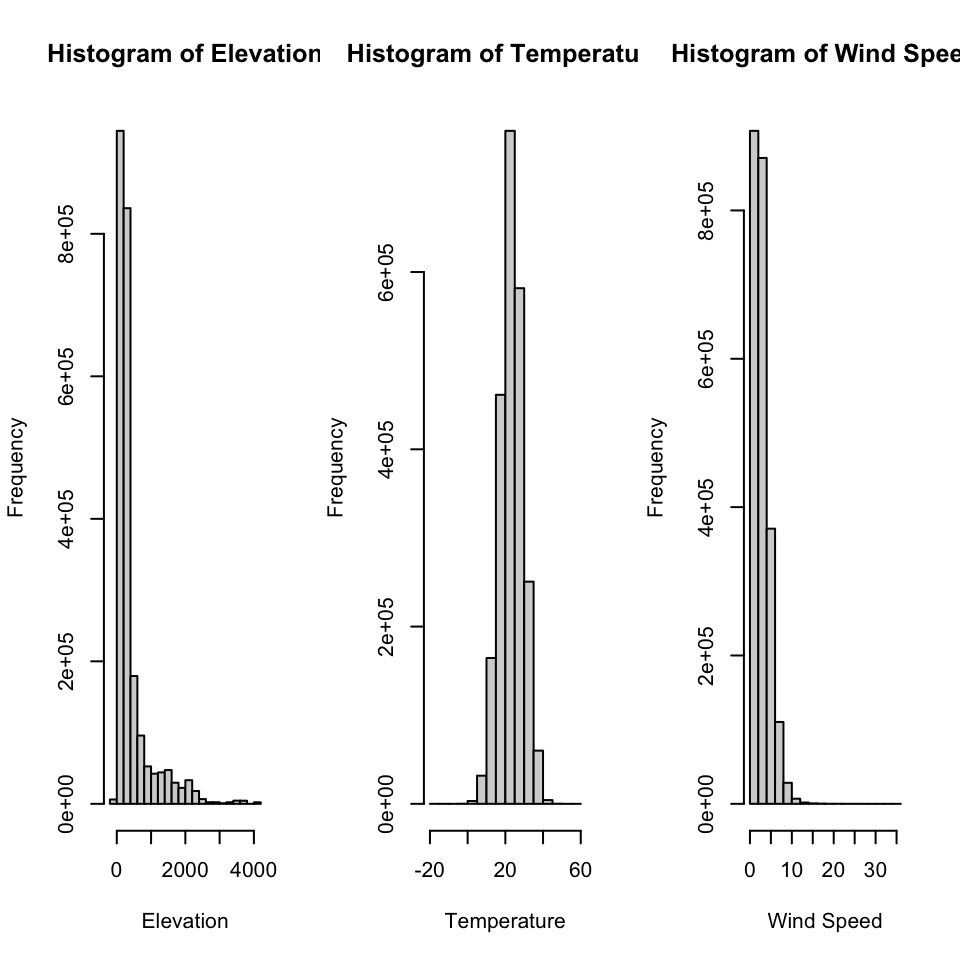

```r
par(mfrow = c(1, 3))

hist(met$elev,
     main = "Histogram of Elevation",
     xlab = "Elevation")

hist(met$temp,
     main = "Histogram of Temperature",
     xlab = "Temperature")

hist(met$wind.sp,
     main = "Histogram of Wind Speed",
     xlab = "Wind Speed")
```

The histogram of elevation shows a right skewed distribution. Temperature appears more symmetrically distributed, and wind speed is strongly right skewed. These distributions suggest that log-transformations of elevation and wind speed may be useful for later analyses.

```r
library(leaflet)

leaflet(max_stat) %>%
  addProviderTiles("OpenStreetMap") %>%
  addCircles(lat = ~lat,
             lng = ~lon,
             opacity = 1,
             fillOpacity = 1,
             radius = 10)
```

[interactive chart not shown]

```r
library(lubridate)
max_stat$date <- with(max_stat,
                      ymd_h(paste(year, month, day, hour, sep = "-")))

summary(max_stat$date)
```

```
                      Min.                    1st Qu.
"2019-08-01 00:00:00.0000" "2019-08-08 10:15:00.0000"
                    Median                       Mean
"2019-08-16 21:00:00.0000" "2019-08-16 13:15:37.8858"
                   3rd Qu.                       Max.
"2019-08-24 09:00:00.0000" "2019-08-31 22:00:00.0000"
```

```r
max_stat <- max_stat[order(max_stat$date), ]

head(max_stat)
```

```
       USAFID WBAN year month day hour min  lat      lon elev wind.dir
221697 720385  419 2019     8   1    0  36 39.8 -105.766 4113      170
221698 720385  419 2019     8   1    0  54 39.8 -105.766 4113      100
221699 720385  419 2019     8   1    1  12 39.8 -105.766 4113       90
221700 720385  419 2019     8   1    1  35 39.8 -105.766 4113      110
221701 720385  419 2019     8   1    1  53 39.8 -105.766 4113      120
221702 720385  419 2019     8   1    2  12 39.8 -105.766 4113      120
       wind.dir.qc wind.type.code wind.sp wind.sp.qc ceiling.ht ceiling.ht.qc
221697           5              N     8.8          5       1372             5
221698           5              N     2.6          5       1372             5
221699           5              N     3.1          5       1981             5
221700           5              N     4.1          5       2134             5
221701           5              N     4.6          5       2134             5
221702           5              N     6.2          5      22000             5
       ceiling.ht.method sky.cond vis.dist vis.dist.qc vis.var vis.var.qc temp
```

[output cut: 20 more lines]

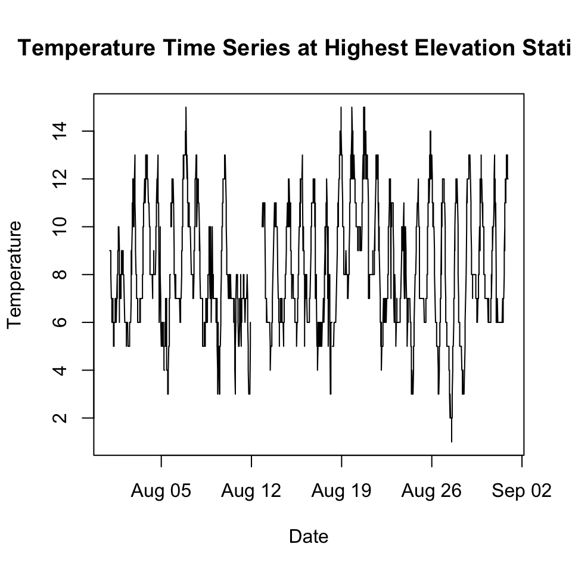

```r
plot(max_stat$date,
     max_stat$temp,
     type = "l",
     xlab = "Date",
     ylab = "Temperature",
     main = "Temperature Time Series at Highest Elevation Station")
```

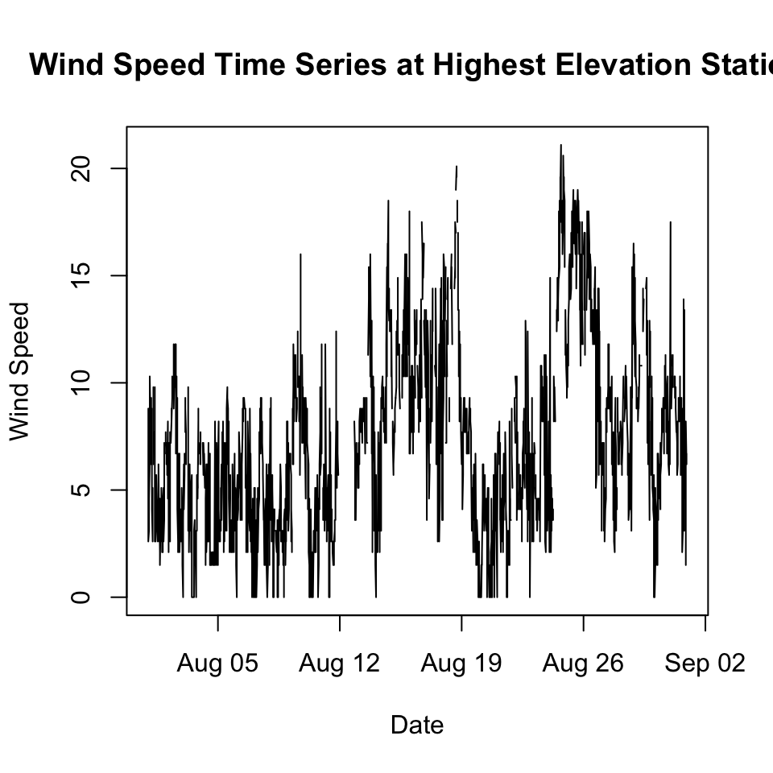

```r
plot(max_stat$date,
     max_stat$wind.sp,
     type = "l",
     xlab = "Date",
     ylab = "Wind Speed",
     main = "Wind Speed Time Series at Highest Elevation Station")
```

## 8. Ask questions

After exploring the dataset, several questions are about how the data were collected and structured. It is unclear whether weather stations are evenly distributed across the country or if certain areas are overrepresented, which could influence relationships between elevation, temperature, and wind speed. Also, the strong skewness in elevation and wind speed raises the question of whether extreme values from a small number of stations may disproportionately affect correlations and summary statistics.